# Looking at Multivariate Data

## 1 The data matrix

## The data: 50 states, 6 variables

|  | Income $ per capita | Illiteracy % | Life exp. years | Murder per 100k | HS grad % | Frost days |
| --- | --- | --- | --- | --- | --- | --- |
| 1 Alabama | 3,624 | 2.1 | 69.0 | 15.1 | 41.3 | 20 |
| 2 Alaska | 6,315 | 1.5 | 69.3 | 11.3 | 66.7 | 152 |
| 3 Arizona | 4,530 | 1.8 | 70.5 | 7.8 | 58.1 | 15 |
| 4 Arkansas | 3,378 | 1.9 | 70.7 | 10.1 | 39.9 | 65 |
| 5 California | 5,114 | 1.1 | 71.7 | 10.3 | 62.6 | 20 |
| ⋮ | ⋮ | ⋮ | ⋮ | ⋮ | ⋮ | ⋮ |
| 43 Texas | 4,188 | 2.2 | 70.9 | 12.2 | 47.4 | 35 |
| ⋮ | ⋮ | ⋮ | ⋮ | ⋮ | ⋮ | ⋮ |
| 50 Wyoming | 4,566 | 0.6 | 70.3 | 6.9 | 62.9 | 173 |

- **Row** \(t\): one state, the column vector \(\mathbf x_t=(x_{t1},\dots,x_{tp})'\) ( Texas). **Column** \(j\): one variable ( murder).
- Entry \(x_{tj}\): Texas has \(x_{43,4}=12.2\) murders per 100,000.

Vectors are **bold**: \(\mathbf x_1\) is the first observation; plain \(x_1\) is the first variable. The prime \('\) is the transpose.

A \(50\times 6\) **data matrix** \(\mathbf X\) (R’s `state.x77`, 1970s): the **sample**.

## Which US state is the most unusual?

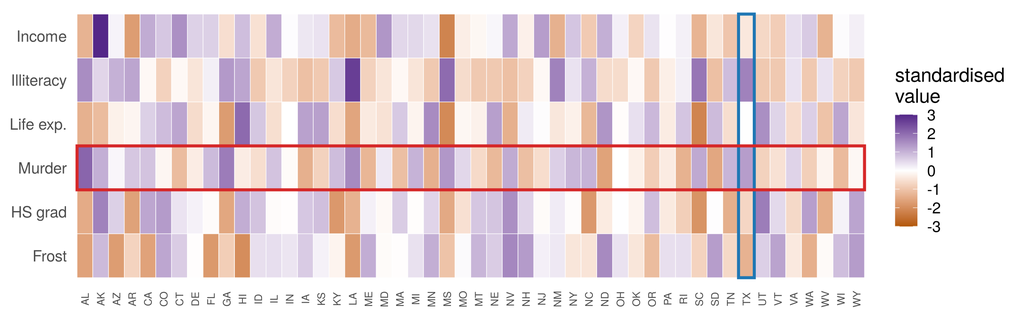

All 300 numbers at once, **standardised** \(z_{tj}=(x_{tj}-\bar x_j)/s_j\): how many standard deviations a state is above (purple) or below (orange) the average.

Which state stands out? Single extreme values are easy to spot; **unusual combinations** are not. We answer at the end.

## Observations are points

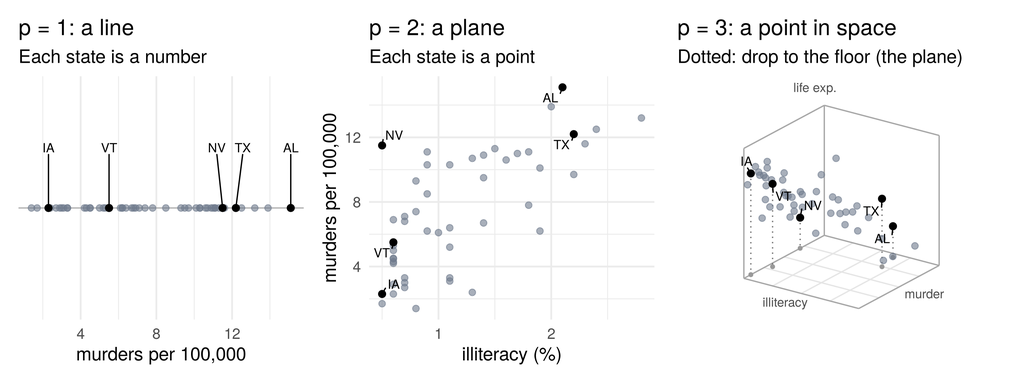

- One variable: a point on a line. Two: in the plane. Three: in space. \(p\): a point in \(p\) dimensions.
- The data matrix is a **cloud of \(n\) points**; this course is about its shape.

## Distance between two observations

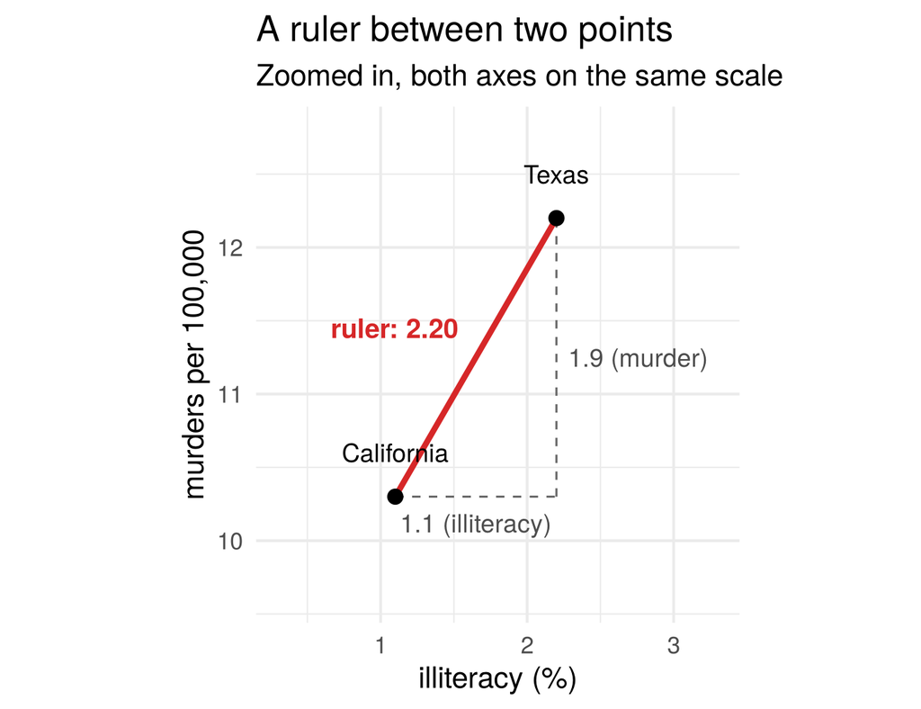

**Euclidean distance**: lay a ruler between the two points. By Pythagoras:

\[\lVert \mathbf x_s-\mathbf x_t\rVert=\sqrt{\sum_{j=1}^p (x_{sj}-x_{tj})^2}\]

In vector form, with \(a'b=\sum_j a_jb_j\) (inner product):

\[\lVert \mathbf x_s-\mathbf x_t\rVert=\sqrt{(\mathbf x_s-\mathbf x_t)'(\mathbf x_s-\mathbf x_t)}\]

Same formula for any \(p\). It depends on the units: the variable with the widest range dominates.

## 2 Types of variables

## Not every column is a number on a line

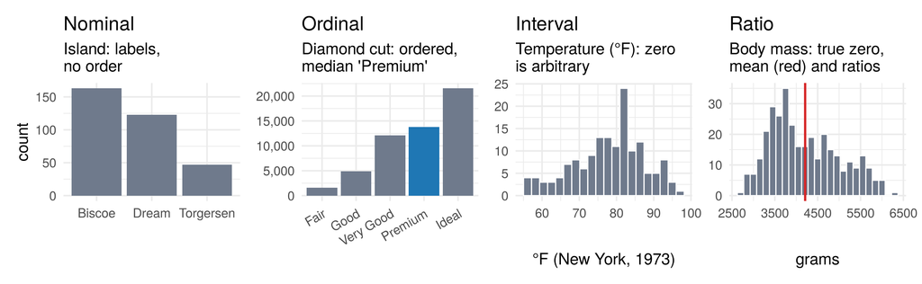

- **Nominal**: labels without order (island, species).
- **Ordinal**: ordered labels, gaps not comparable (diamond cut, survey answers).
- **Interval**: equal steps, arbitrary zero (temperature in °F).
- **Ratio**: true zero, so ratios make sense (body mass, income, murder rate).

Binary: a nominal variable with two categories (coded 0/1, its mean is a share). Count: ratio-scaled, whole numbers only.

## Why the type matters

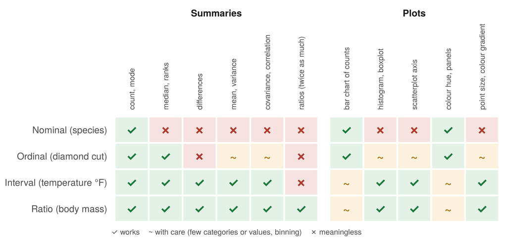

Numbers on a scale: means, covariances, axes, sizes. Categories: **count**, **colour** or **split**.

## Categorical variables in R: factors

```r
island <- factor(c("Dream", "Biscoe",
                   "Dream", "Torgersen"))
levels(island)       # stored once
```

```
## [1] "Biscoe"    "Dream"     "Torgersen"
```

```r
as.integer(island)   # codes per row
```

```
## [1] 2 1 2 3
```

A **factor** stores the categories once (its **levels**) and a whole-number code per observation.

- Smaller and faster than repeated text
- A fixed set of categories: typos become `NA`
- Level order sets table and legend order; `ordered = TRUE` for ordinal
- Models create the dummy variables automatically

## 3 A plot for each type

## One plot does not fit all types

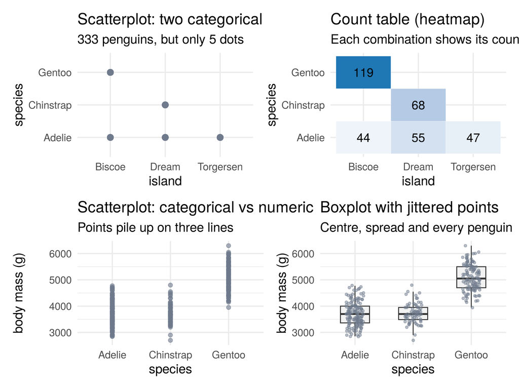

**Two categorical**: a scatterplot shows 333 penguins as 5 dots. Show **counts**.

**Categorical + numeric**: points pile up on lines. Use **boxplots** (plus jittered points).

**Two numeric**: the **scatterplot** is the right tool.

## Many numeric variables: the scatterplot matrix

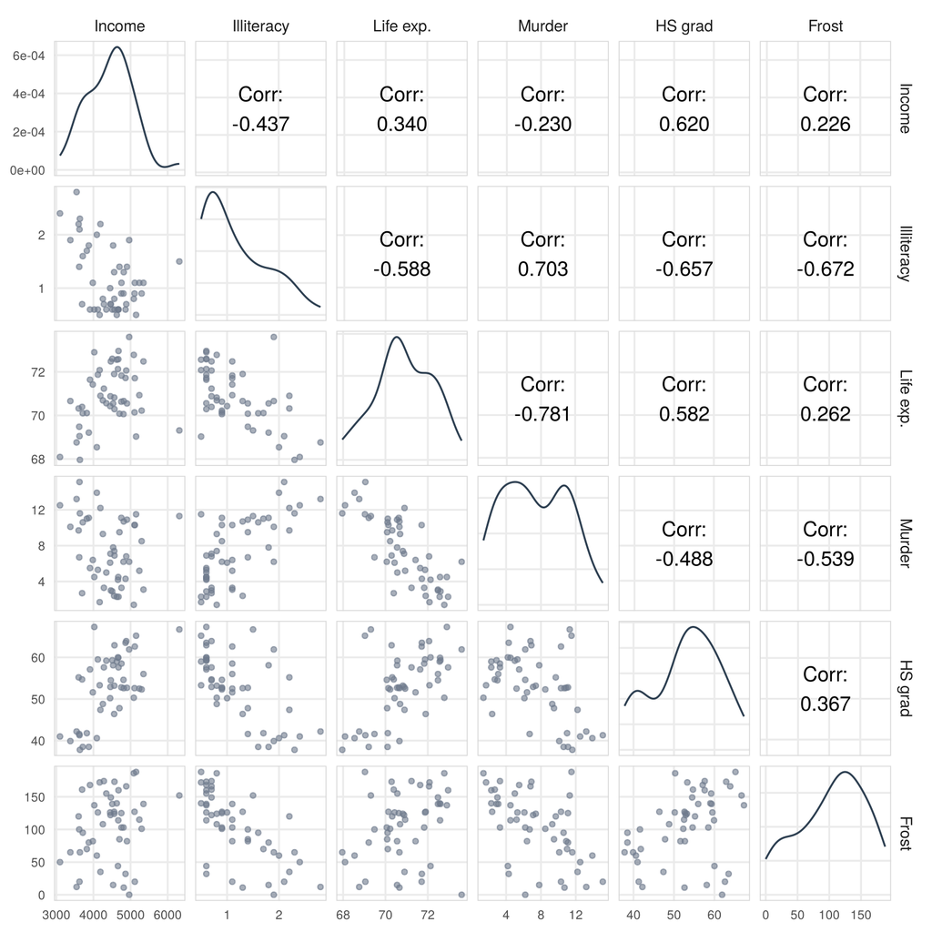

\(p\) variables, \(p(p-1)/2\) pairs: every pair once below the diagonal, correlations above.

- Illiteracy, murder, life expectancy and graduation all move **together**.
- Frost goes with low illiteracy (northern states).

Pairs are 2D. What about three variables at once?

## 4 A third variable, in two dimensions

## Why not just plot in 3D?

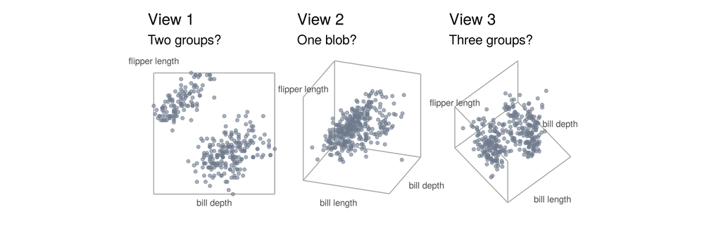

- 333 penguins: bill (beak) length and depth, flipper length. Three angles, three different stories. Depth is guessed, points hide, values cannot be read off.

Humans read 2D well. Keep two axes; show the third variable in a way that fits its **type**: categorical → **colour** or **panels**, numeric → **size** or colour **gradient**.

## The same three variables in 2D

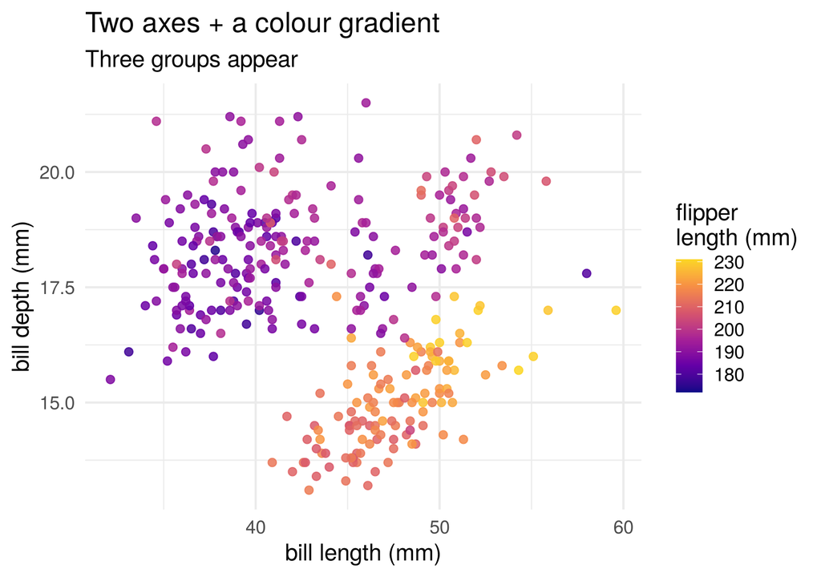

Two numeric variables on the axes; the third (flipper length, also numeric) as a colour **gradient**.

One flat picture, values can be read off: **three groups**, which no single 3D view showed clearly.

## Categorical third variable: colour

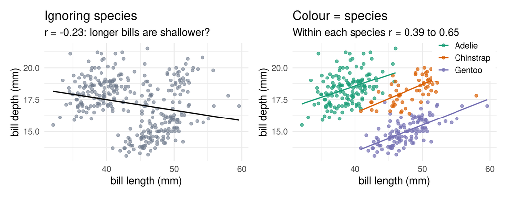

- Overall \(r = -0.23\), but **positive** within every species: **Simpson’s paradox**.
- **Grouped scatterplot**: one hue per category, `aes(colour = species)`. Hues have no order: fine for nominal.

## Numeric third variable: size

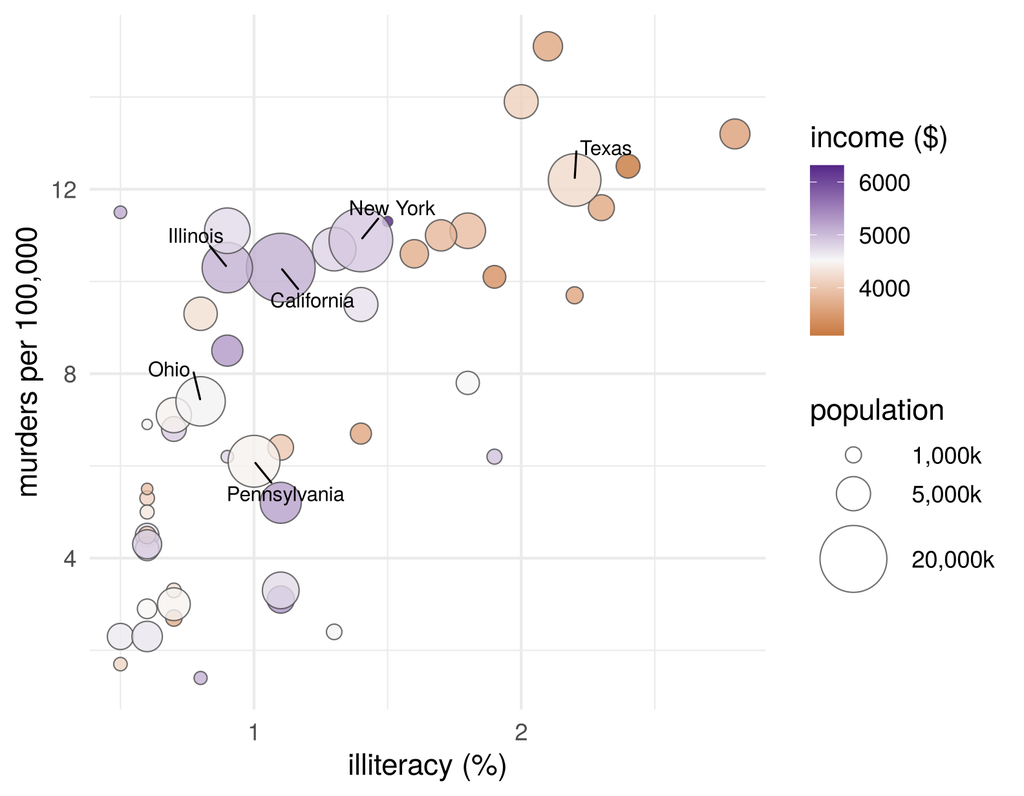

Hues cannot show **how much**. A numeric variable needs an order and a scale: **size** or a colour **gradient**.

**Bubble plot**: position = illiteracy, murder; size = population; gradient = income.

`aes(size = Population, fill = Income)`. Crowds quickly; areas are hard to compare.

## Categorical third variable: panels

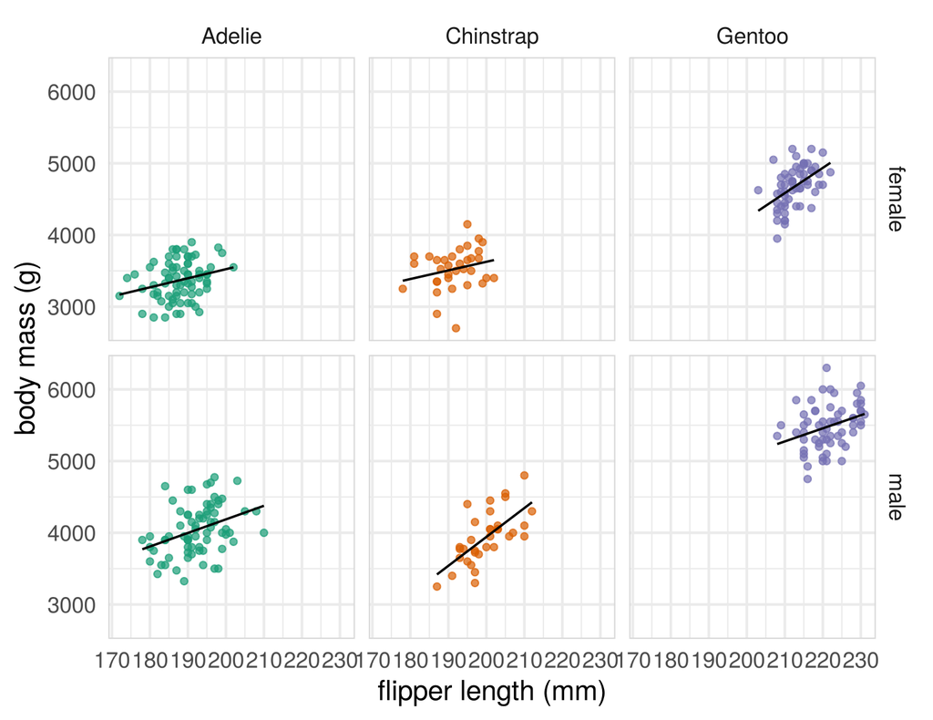

**Conditioning plot**: one panel per category (species × sex), same axes everywhere.

- Within each panel: heavier penguins have longer flippers.
- Across panels: Gentoo are larger, males heavier.

Also called **trellis** plots (`lattice`), **facet** plots (ggplot2: `facet_wrap()`, `facet_grid()`) or small multiples.

## Same idea in other tools

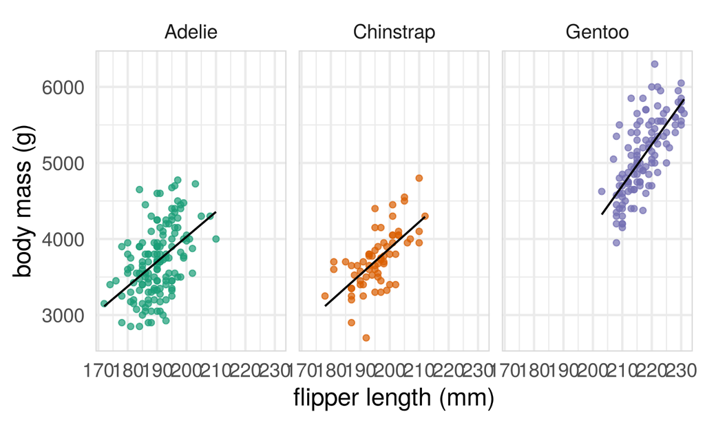

**Facet plot**, one variable:  
`facet_wrap(~ species)`

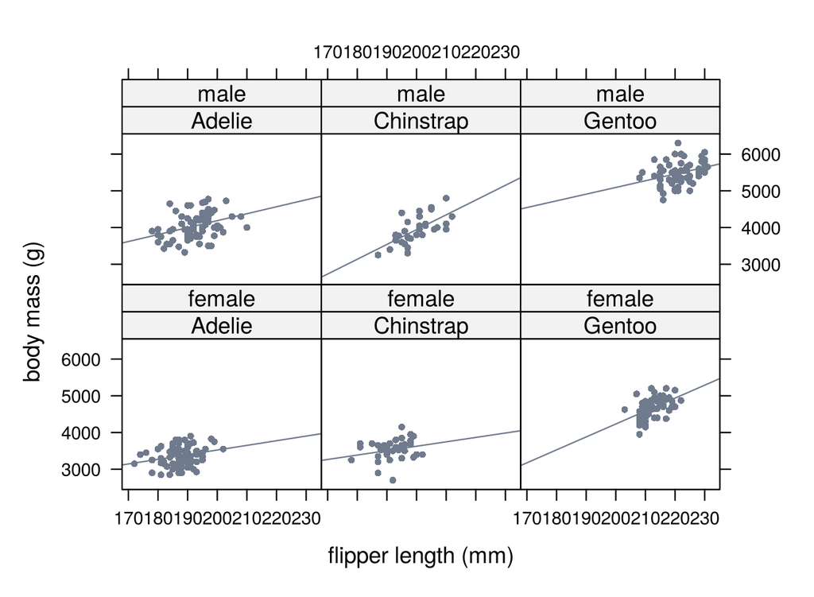

**Trellis plot** (`lattice`):  
`xyplot(mass ~ flipper | species * sex)`

## 5 Summaries of the cloud

## Mean and standard deviation

**Sample mean** of variable \(j\) and the **mean vector**, the centre of the cloud:

\[\bar x_j=\frac1n\sum_{t=1}^n x_{tj},\qquad \bar{\mathbf x}=\begin{pmatrix}\bar x_1\\ \vdots\\ \bar x_p\end{pmatrix}=\frac1n\sum_{t=1}^n \mathbf x_t\]

**Sample variance** and **standard deviation**, the typical distance from the mean:

\[s_j^2=\frac{1}{n-1}\sum_{t=1}^n (x_{tj}-\bar x_j)^2,\qquad s_j=\sqrt{s_j^2}\]

Murder: \(\bar{\mathbf x}=7.4\), \(s=3.69\) per 100,000. \(s\) is in the units of the variable.

## Covariance: the average product

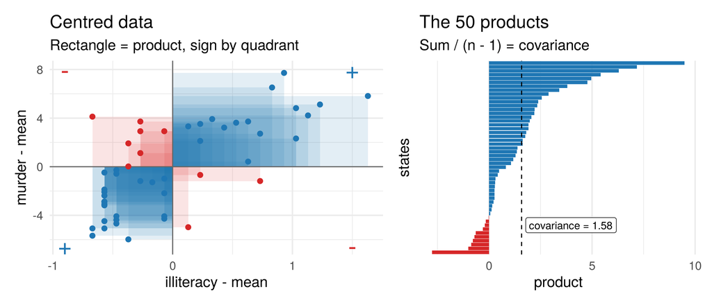

\[ s_{jk}=\frac{1}{n-1}\sum_{t=1}^n (x_{tj}-\bar x_j)(x_{tk}-\bar x_k) \qquad\text{illiteracy and murder: } s = 1.58 \]

## The sample covariance matrix

All variances (diagonal) and covariances (off the diagonal):

\[ S=\begin{pmatrix} s_1^2 & s_{12} & \cdots & s_{1p}\\ s_{21} & s_2^2 & \cdots & s_{2p}\\ \vdots & & \ddots & \vdots\\ s_{p1} & s_{p2} & \cdots & s_p^2\end{pmatrix} =\frac{1}{n-1}\sum_{t=1}^n (\mathbf x_t-\bar{\mathbf x})(\mathbf x_t-\bar{\mathbf x})' \]

- A column times a row, \(ab'\), is a \(p\times p\) matrix with entries \(a_jb_k\) (**outer product**): entry \((j,k)\) of each term is \((x_{tj}-\bar x_j)(x_{tk}-\bar x_k)\).
- \(S\) is symmetric. It describes the **shape** of the cloud, as \(\bar{\mathbf x}\) describes its centre.

## Correlation: covariance without units

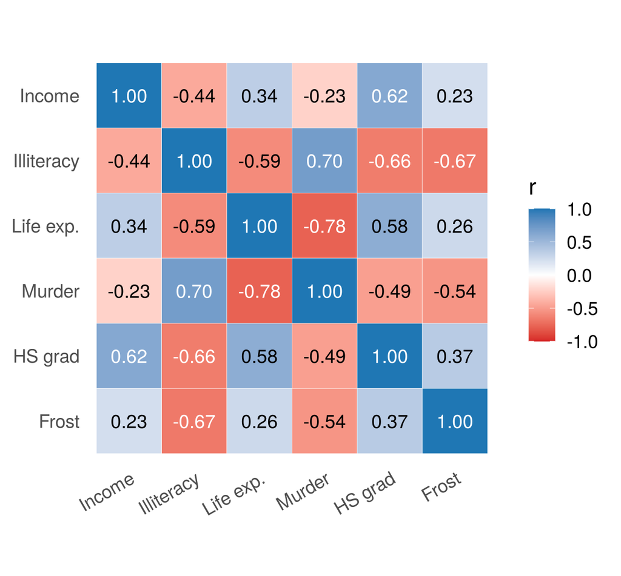

Covariance carries the units of both variables (dollars times days…). Divide by the standard deviations:

\[r_{jk}=\frac{s_{jk}}{s_j\,s_k}\in[-1,1]\]

Same as the covariance of **standardised** values \(z=(x-\bar{\mathbf x})/s\).

All correlations form the matrix \(R\), ones on the diagonal. With \(D=\operatorname{diag}(s_1,\dots,s_p)\):

\[R=D^{-1}SD^{-1}\]

## Correlation is an average of products

[interactive chart not shown]

Move the slider. Each point is coloured by its product \(z_{t1}z_{t2}\):

- blue: same side of the mean on both variables, pulls \(r\) up
- red: opposite sides, pulls \(r\) down

The thinner the ellipse, the larger \(|r|\).

## What correlation misses

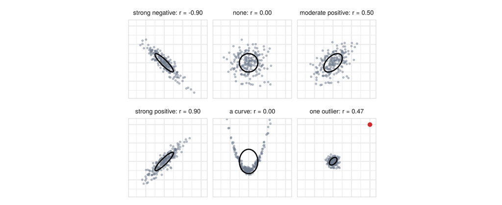

- \(r\) measures **linear** association only: a perfect curve can have \(r\approx 0\).
- A single point can create a correlation. **Always look at the scatterplot.**

## 6 Unusual combinations

## Hawaii: ordinary on each variable

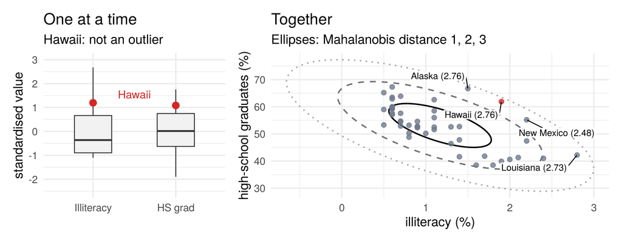

Hawaii: \(z = 1.20\) and \(1.09\), within the whiskers, so no outlier. But high illiteracy usually comes with **few** graduates (\(r=-0.66\)); Hawaii has many.

## From Euclidean to Mahalanobis distance

**Euclidean** distance from the centre treats every direction alike:

\[\sqrt{(\mathbf x_t-\bar{\mathbf x})'(\mathbf x_t-\bar{\mathbf x})}\]

**Mahalanobis** distance puts \(S^{-1}\) in the middle:

\[d_t=\sqrt{(\mathbf x_t-\bar{\mathbf x})'S^{-1}(\mathbf x_t-\bar{\mathbf x})}\]

- The cloud is an ellipse: a step along its long axis is normal, the same step across it is far out.
- \(S^{-1}\) (with \(S^{-1}S=I\), R: `solve(S)`) shrinks differences where the cloud is wide and stretches them where it is narrow.
- Uncorrelated, standardised variables: \(S=I\), and \(d_t\) is the Euclidean distance.

## Mahalanobis distance: two variables

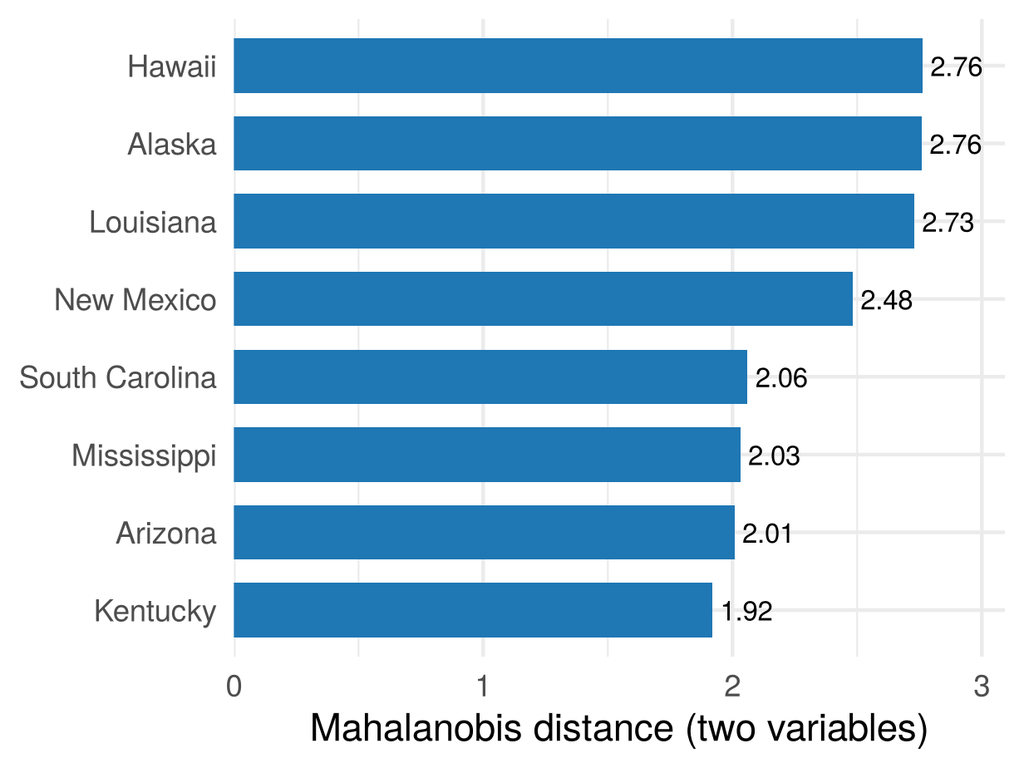

Distance from the centre in units of the **cloud’s own shape**.

Equal \(d_t\): one ellipse. Further-out ellipse, larger \(d_t\): same order as in the scatterplot.

Hawaii and Alaska lie **across** the cloud; Louisiana beyond its end.

## Mahalanobis distance: all six variables

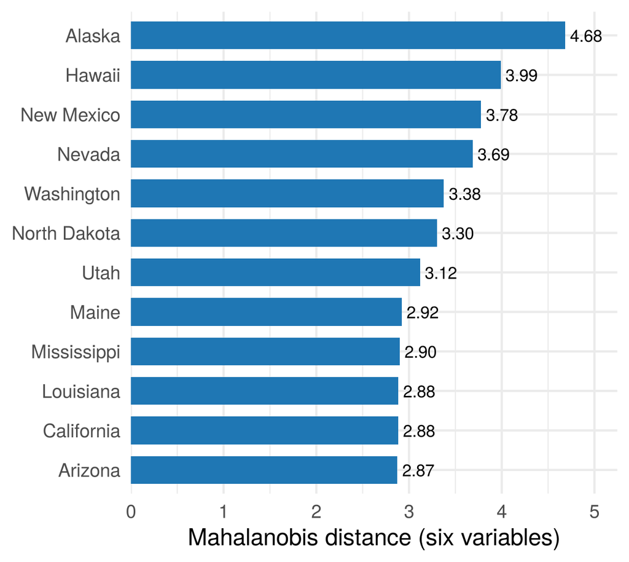

The same formula with \(p=6\): no picture, but the same idea.

**Alaska** is farthest, then Hawaii, New Mexico and Nevada.

Is a distance of 4.7 surprising? That needs a model of where the data come from: next lecture.

## Summary

## Takeaways

- A data set is an \(n\times p\) **data matrix**: a cloud of \(n\) points in \(p\) dimensions.
- **Types** of variables: nominal, ordinal, interval, ratio. Means, covariances and distances need numbers on a scale.
- The type decides the **plot**: counts, boxplots, scatterplots, scatterplot matrices.
- 3D is hard to read: show a third variable in 2D, fitted to its type: **colour** or **panels** (categorical), **size** (numeric).
- Each observation is a point; the **Euclidean distance** is the ruler between two points.
- **Mean vector** \(\bar{\mathbf x}\), **covariance matrix** \(S\), **correlation matrix** \(R\) summarise the cloud; correlation captures only linear co-movement, so always look at the plot.
- The **Mahalanobis distance** measures distance relative to the shape of the cloud and finds unusual combinations: Hawaii, and with six variables Alaska.